# Co-expression network analysis with R

Thomas Mohr

SS2021

# 1 Co-expression network analysis with R

## 1.1 Scope of the lecture

- What is Co-expression analysis ?
- How to get and prepare the data
- Network concepts
- Methods of co-expression analysis
  - WGCNA
  - ARACNe
  - GeneNet
- practical example:
  - Data preparation
  - WGCNA
  - GeneNet
  - Biologic context of modules

## 1.2 Time frame

- Afternoon 1: General concepts
- Afternoon 2: Practical work
- Afternoon 3: Practical work
- Afternoon 4: Practical work - discussion

# 2 What is Gene Co-expression Analysis ?

## 2.1 The ratio behind co-expression analysis

- Genes act in cooperation and not individually
- These cooperating units can be viewed as modules of genes
- Pathways are a subtype of modules, but cross pathway communication is largely a terra icognita → using modules may overcome this shortcoming.
- Network based methods instead of reporting a list of individual parts are a natural approach to understanding such a “system”.
- Focus on modules as opposed to individual genes → this greatly alleviates multiple testing problem

## 2.2 What is a Gene Regulatory Network ?

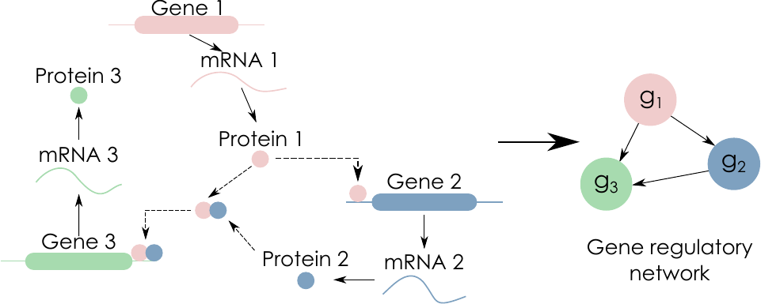

Gene regulatory network

## 2.3 A few network concepts - network types

A network or graph is a pair (V,E), where V is a set of vertices (or nodes) and E is a set of edges connecting the vertices

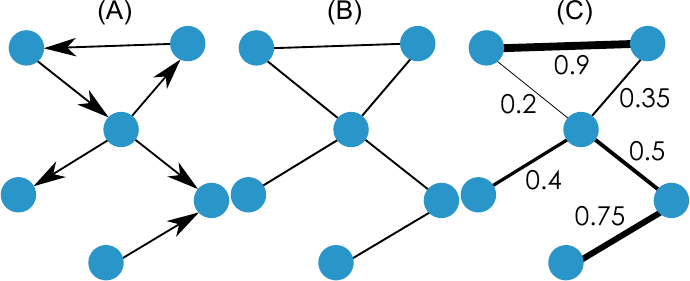

Types of networks

1. represents a directed network, (B) an undirected network, and (C) represents a weighted network with edge weight represented by edge thickness.

# 3 Network concepts

## 3.1 Z transformation

- Formula: $z=\frac{x-\overline{x}}{s}$
- Transforms a dataset into a gaussian distribution (mean = zero, standard deviation = 1)
- Enables the comparison between values of different distributions and locations: mean +/- 2s ~ p-value of < 0.05 → quick‘n dirty test for statistical significance
- We will use the prefix „z“ as denominator of z-transformed values

## 3.2 Adjacency

The adjacecy is a measure how strongly two nodes are connected.

In co-expression networks, correlations are often used to construct an adjacency matrix:

- unsigned $a_{ij} = |cor(x_i, x_j)|^\beta$
- signed $a_{ij} = |0.5+0.5cor(x_i, x_j)|^\beta$

## 3.3 Scale free topology

In a scale free network the degree function follows

$$P(k) \sim K^\lambda$$

That means that there are

- few highly connected nodes
- many less connected nodes.

Scale free networks can be found in many situations such as protein interaction, traffic and social networks

## 3.4 Correlation networks

Given two vectors v<sub>i</sub> and v<sub>j</sub>, the pearson correlation is given as

$$\rho_{i,j} =
\frac{v_{i}.v_{j}}{||v_{i}||.||v_{j}||}$$

In practice, a set of *N* samples and *G* genes gives a *GXG* matrix of pairwise gene correlations. Other correlations measures may be the Spearman or the Kendall correlation coefficient.

Example: Weighted Gene Coexpression Network Anaylsis

Limitations:

- Correlations because of common regulators: g -> j -> k translates into g -> k
- Limited sample sizes may produce correlations that are not significant.

## 3.5 Information theory based networks

The mutual information between two variables is defined as

$$MI[X,Y] = \sum_{x_{i}, y_{i}}P(x_i,
y_i)log\frac{P(x_i,y_i)}{P(x_i)P(y_i)}$$
With P being the probability functions of the variables. The mutual information is a measure for the dependency of one gene on the other.

Examples: ARACNe, MRNET and CLR

Limitations:

- computationally expensive
- sometimes sensitive to noise

## 3.6 Regression based networks

regression based networks calculate the edge weight based on a regression model

$$x_{gi} = \sum_{i\neq
g}w_jx_{ij}+\epsilon_{i}$$

The regression formula gives directed gene regulator networks.

Examples: TIGRESS and GENIE3

Limitations:

- Directed networks
- computationally expensive
- require a sufficient number of samples

## 3.7 Gaussian Graphical Models

this approach uses multivariate normal distributions (Gaussians) described by

$$p(x|m,\Sigma) =
\frac{1}{\sqrt{2\pi|\Sigma}}exp[-\frac12(x-m)^T\Sigma^{-1}(x-m)]$$
To determin the edge weights the partial correlation matrix is used. The *partial correlation* between two genes is the correlation that remains if the effect of all other genes is removed.

Limitations:

- Does not work on non normal data
- Assumes a linear regulation between genes
- Needs a sufficiently high number of samples.

## 3.8 Bayesian Networks

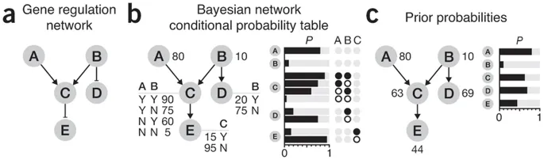

Bayesian networks. calculation of prior probabilities

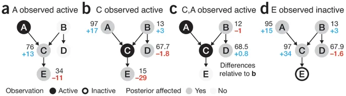

Bayesian networks. posterior probabilities in a sample can be calculated using the given network

- Limitations
  - computationally expensive, do not scale well
  - network structure difficult to determin

## 3.9 Dynamic Bayesian Networks

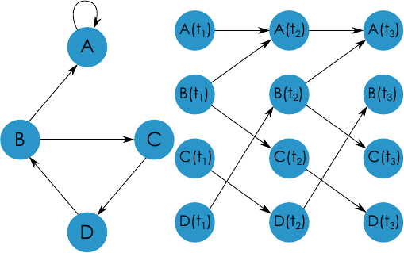

Example of a Dynamic Bayesian Network with four nodes: static representation (with cycles) on the left, and unrolled dynamic representation on the right.

Limitations

- extremely computational expensive
- Assumption of a linear dynamic kinetics - patiularly time points

## 3.10 Differential equations

Differential equation models are described by the function
$$\frac{dX}{dt}=f(x,\Theta, u(t), t)$$
with x being the gene expression, $\Theta$ a set of parameters, u(t) a set of external signals, and the time t.

# 4 Implementations

## 4.1 Tools

| Tool | Type | Implementations |
| --- | --- | --- |
| WGCNA | Correlation network | R package |
| ARACne | Mutual Information Network | Java |
| CLR | Mutual Information Network | Matlab |
| MRNET | Mutual Information Network | R package |
| GENIE3 | Tree based | MATLAB, R, and python |
| GeneNet | Gaussian Graphical Models | R package |
| CatNet | Bayesian networks | R package |
| Banjo | Bayesian networks | Java |
| G1DBN | Dynamic Bayesian Networks | R package |
| GRENITS | Dynamic Bayesian Netwoks | R package |
| TSNI | Differential equations based | MATLAB |
| Inferelator | Differential equations based |  |

## 4.2 Benchmarking

Benchmarking tool: netbenchmark, for benchmarking GRN performance

# 5 Weighted Gene Co-expression Network Analysis

## 5.1 How to check scale free topology ?

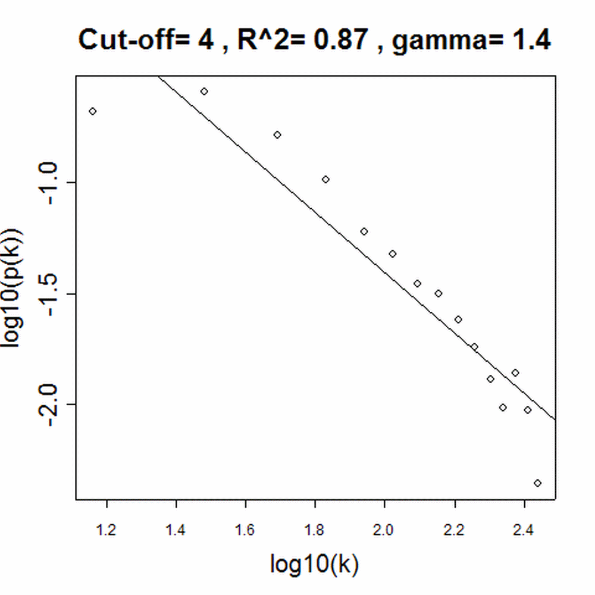

correlation plot of log transformed p(k) and k

- Idea: log transform p(k) and k
- $log(p(k)) \sim -\lambda log(k)$
- The correlation coefficient squared ($r^2$) can be used as index to quantify the goodness of fit
- In reality, one would chose $\beta = 1,2,3,...,n$ and calculate $r^2$ for each $\beta$.
- A $\beta$ leading to an $r^2$ of larger than 0.85 would be chosen

## 5.2 Network concepts - Gene Segnificance

Gene significance denotes the significance of a gene for a given scientific question. In general it can be calculated by:

$$GS_i = -log(pvalue_i)$$

The only assumption is that $GS_i = 0$ denotes nodes that are not significant for a given process.

However, $GS_i$ could also be an indicator that equals 1 if prior knowledge suggests that node i is known to be important and 0 otherwise.

## 5.3 The topological overlap dissimilarity is used as input of hierarchical clustering

What is the topological overlap ?

The topological overlap describes how many neihgbours are shared between two nodes:

$$TOM_{ij} =
\frac{\sum{a_{iu}a_{uj}}+a_{ij}}{min(k_i, k_j) + 1 -
a_{ij}}$$

The TOM based distance is calculated by

$$DistTOM_{ij} = 1 - TOM_{ij}$$

## 5.4 Intramodular Connectivity

Intramodular connectivity kIN with respect to a given module (say the Blue module) is defined as the sum of adjacencies with the members of the module.

For unweighted networks=number of direct links to intramodular nodes

For weighted networks= sum of connection strengths to intramodular nodes

$$kIN_i^{module} = \sum_{j \in
module}a_{ij}$$

## 5.5 Module significance

The module significance is the mean gene significance of the members of the module

The module significance measure can be used to address a major goal of gene network analysis: the identification of biologically significant modules or pathways.

# 6 Example

# 7 Putting modules into biologic context

## 7.1 Unsupervised co-expression analysis

## 7.2 Supervised co-expression analysis

- Modules are predefined based on pathways, GO-terms, etc.
- The workflow is the same, except for the clustering and module detection which is replaced by the module definition step
- The network concepts (intramodular connectivity, adjacency, density) are the same
- Supervised co-expression analysis mostly compares several networks

## 7.3 Hepatocellular carcinoma associated endothelial cells

# 8 Conclusion

## 8.1 Take home message

We have implemented several algorithms able to deduce gene regulatory networks from given data, provided the sample size is large enough.